# The comparison of differentially methylated bases detection tools on simulated data

# Visualisation

Visualise sensitivity, specificity and F-score for different effect sizes.

```r
models.res=models.res.orig
models.res.diff=models.res.diff.orig

# Convert list of matrices to a data.frame
models.res.ma = do.call("rbind", models.res)
models.res.df = data.frame(models.res.ma)
models.res.df = cbind(models.res.df,
                      tool=rownames(models.res.ma),
                      effect=as.factor(as.numeric(sapply(effects,
                                               function(x)
                                                 rep(x, nrow(models.res[[1]])  )))))

# Plot the True/false positives/negatives that were computed
msel = models.res.df[,c('TP','FN','FP','TN','tool', 'effect')]
mseldat <- melt(msel, id.vars=c("tool","effect"))
metrics = ggplot(mseldat, aes(variable, value, fill=tool)) +
  geom_bar(stat="identity", position="dodge",colour="black",
           width=0.65)+
  scale_fill_manual(values=cbPalette)+
  labs(y="Number", x="Metric",fill='Tool')+
  facet_wrap(~effect, nrow=1)+
  theme(legend.position = "none")
```

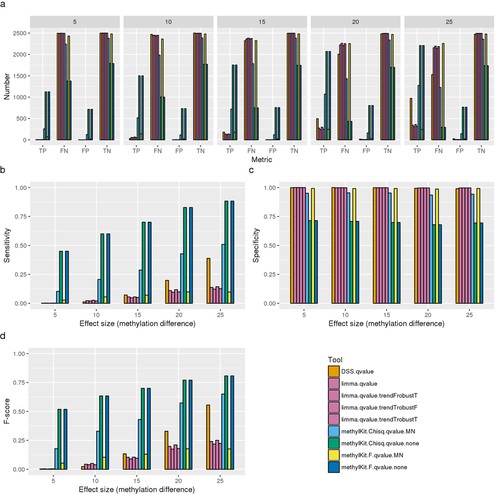

```r
# 1. Create the plots for sensitivity, specificity and F-score
#++++++++++++++++++++++++++++++++++

# A palette
cbPalette <- c( "#E69F00", "#CC79A7", "#CC79A7", "#CC79A7","#CC79A7","#56B4E9", "#009E73", "#F0E442", "#0072B2", "#D55E00", "#CC79A7")

p_sens<-ggplot(models.res.df,aes(effect, sens, fill=tool))+
  geom_bar(stat="identity",position='dodge',colour="black",
           width=0.65)+
  coord_cartesian(ylim=c(0.0,1.00))+
  scale_fill_manual(values=cbPalette)+
  labs(y="Sensitivity", x="Effect size (methylation difference)",fill='Tool')

p_spec<-ggplot(models.res.df,aes(effect, spec, fill=tool))+
  geom_bar(stat="identity",
           position="dodge",
           colour="black",
           width=0.65)+
  coord_cartesian(ylim=c(0.0,1.00))+
  scale_fill_manual(values=cbPalette)+
  labs(y="Specificity", x="Effect size (methylation difference)",fill='Tool')+
  theme(legend.position = "none")

p_recall <- ggplot(models.res.df,aes(effect, recall, fill=tool))+
  geom_bar(stat="identity",position='dodge',colour="black",
           width=0.65)+
  coord_cartesian(ylim=c(0.0,1.00))+
  scale_fill_manual(values=cbPalette)+
  labs(y="Recall", x="Effect size (methylation difference)",fill='Tool')+
  theme(legend.position = "none")

p_fscore <- ggplot(models.res.df,aes(effect, f_score, fill=tool))+
  geom_bar(stat="identity",position='dodge',colour="black",
           width=0.65)+
  coord_cartesian(ylim=c(0.0,1.00))+
  scale_fill_manual(values=cbPalette)+
  labs(y="F-score", x="Effect size (methylation difference)",fill='Tool')+
  theme(legend.position = "none")


# 2. Save the legend
#+++++++++++++++++++++++
get_legend<-function(myggplot){
  tmp <- ggplot_gtable(ggplot_build(myggplot))
  leg <- which(sapply(tmp$grobs, function(x) x$name) == "guide-box")
  legend <- tmp$grobs[[leg]]
  return(legend)
}
legend <- get_legend(p_sens)
# 3. Remove the legend from the box plot
#+++++++++++++++++++++++
p_sens <- p_sens+ theme(legend.position="none")


p_metrics1 <- arrangeGrob(metrics, top = textGrob("a", x=unit(0, "npc"),y=unit(1, "npc"),
                                               just=c("left","top"), gp=gpar(col="black", fontsize=14)))

p_sens1 <- arrangeGrob(p_sens, top = textGrob("b", x=unit(0, "npc"),y=unit(1, "npc"),
                                               just=c("left","top"), gp=gpar(col="black", fontsize=14)))
p_spec1 <- arrangeGrob(p_spec, top = textGrob("c", x=unit(0, "npc"),y=unit(1, "npc"),just=c("left","top"), gp=gpar(col="black", fontsize=14)))
p_fscore1 <- arrangeGrob(p_fscore, top = textGrob("d", x=unit(0, "npc"),y=unit(1, "npc"),just=c("left","top"), gp=gpar(col="black", fontsize=14)))

grid.arrange(p_metrics1,
             p_sens1, p_spec1,
             p_fscore1, legend,
             ncol = 2, nrow=3,
             layout_matrix = rbind(c(1,1),c(2,3), c(4,5)),
             widths=c(1,1))
```

Visualise intersections between DMCs from given tools for calling differentiall methylated cytosines for different effect sizes:

- 5
- 10
- 15
- 20
- 25

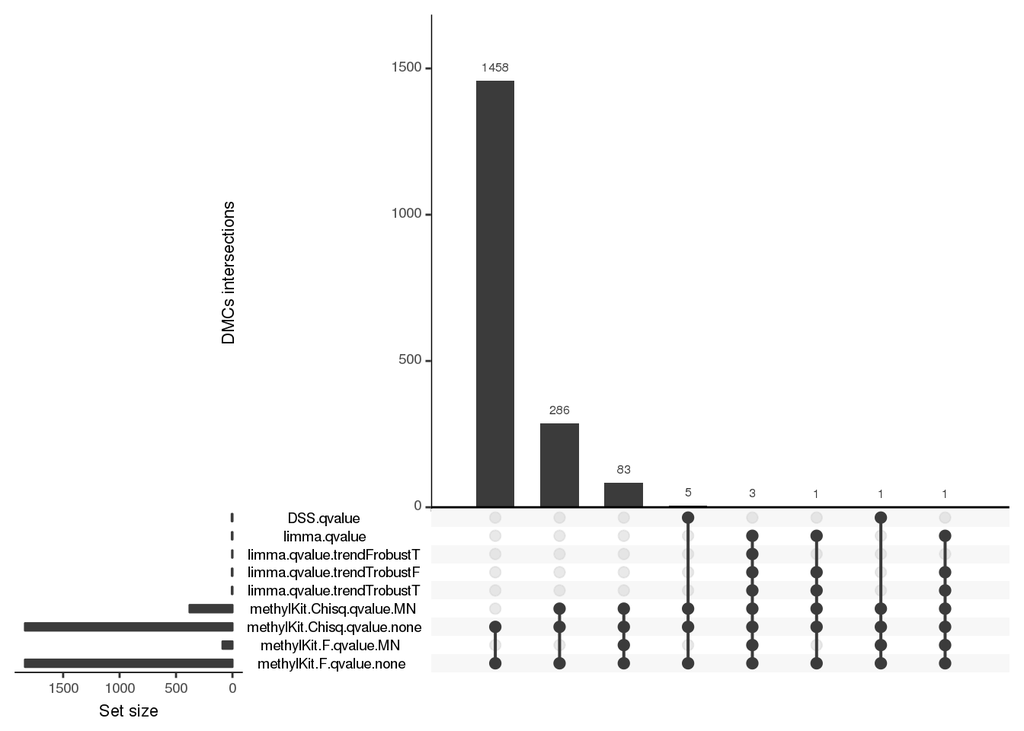

```r
source("./functions/vis.R")

names_sets = rev(sort(as.character(levels(models.res.df$tool)))) # to plot tools in the same order as in barplots

plot.intersetion.tools(models.res.diff[['5']], vis=TRUE, keep.order=TRUE, sets = names_sets)
```

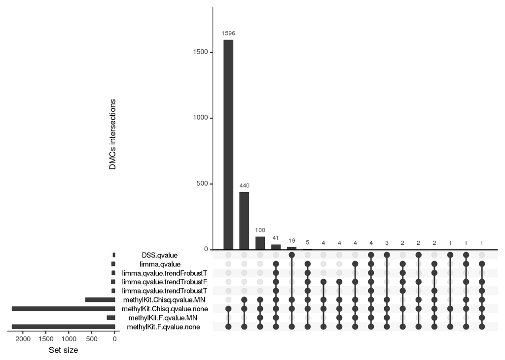

```r
plot.intersetion.tools(models.res.diff[['10']], vis=TRUE, keep.order = TRUE, sets = names_sets)
```

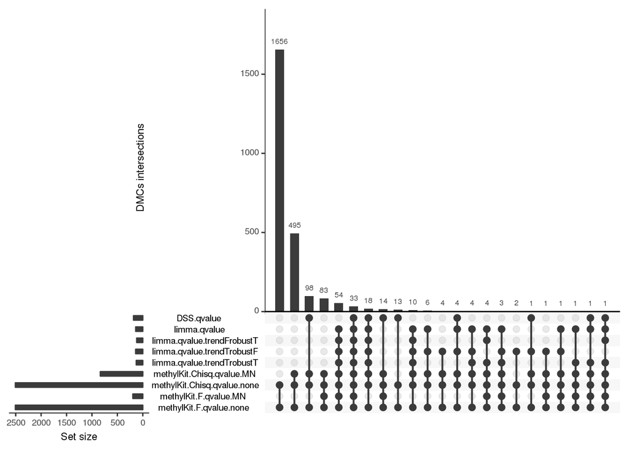

```r
plot.intersetion.tools(models.res.diff[['15']], vis=TRUE, keep.order = TRUE, sets = names_sets)
```

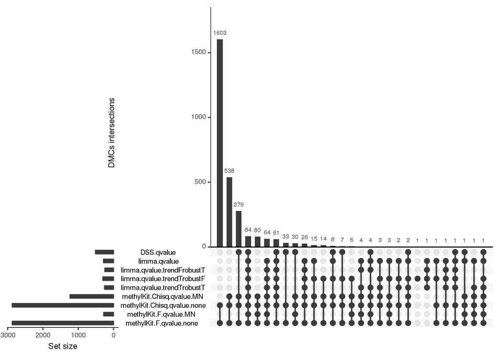

```r
plot.intersetion.tools(models.res.diff[['20']], vis=TRUE, keep.order = TRUE, sets = names_sets)
```

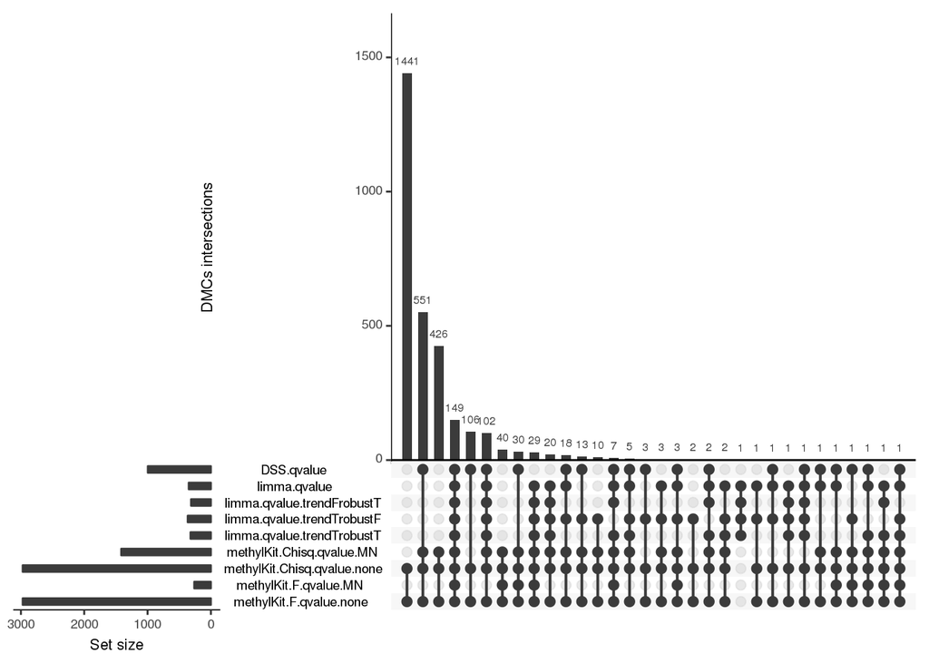

```r
plot.intersetion.tools(models.res.diff[['25']], vis=TRUE, keep.order=TRUE, sets = names_sets)
```

# Results

Visualise sensitivity, specificity and F-score for different effect sizes.

Limma performs very similar for all combinations of input argument trend=TRUE/FALSE and robust=TRUE/FALSE and we here chose trend=TRUE and robust=TRUE. methylKit with F-test was removed since it performs almost identical to methylKit with Chisq test.

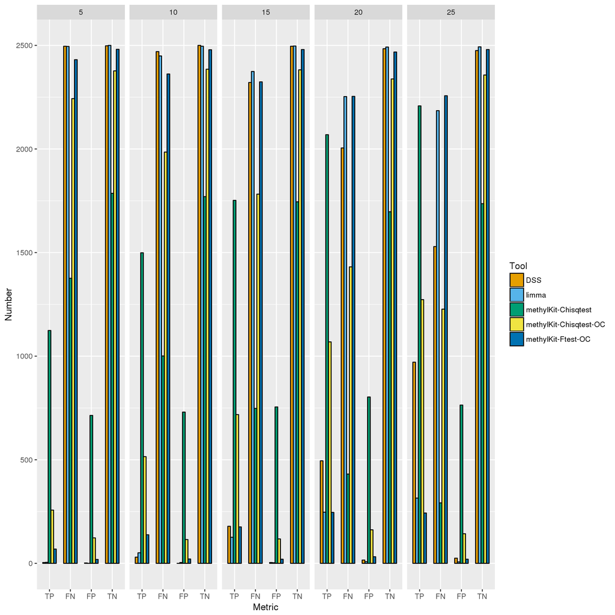

```r
models.res.diff=models.res.diff.orig
models.res=models.res.orig

wh.exlc = which(names( models.res.diff[[1]] ) %in% c("methylKit.F.qvalue.none","limma.qvalue","limma.qvalue.trendTrobustF","limma.qvalue.trendFrobustT"))
for( i in 1:length(models.res.diff)){
    models.res.diff[[i]] = models.res.diff[[i]][-wh.exlc]
    models.res[[i]] = models.res[[i]][-wh.exlc,]
}

# Rename names of tools
old.v=c("DSS.qvalue", "limma.qvalue.trendTrobustT","methylKit.F.qvalue.none", "methylKit.Chisq.qvalue.MN","methylKit.Chisq.qvalue.none", "methylKit.F.qvalue.MN", "methylKit.F.qvalue.none")
new.v=c("DSS",      "limma"   ,"methylKit-Ftest", "methylKit-Chisqtest-OC", "methylKit-Chisqtest", "methylKit-Ftest-OC", "methylKit-Ftest")
names(new.v) = old.v

for( i in 1:length(models.res.diff)){
    names( models.res.diff[[i]] ) = new.v[ match( names( models.res.diff[[i]] ), old.v ) ]
    rownames( models.res[[i]] ) = new.v[ match(  rownames( models.res[[i]] ), old.v ) ]
}

# Convert list of matrices to a data.frame
models.res.ma = do.call("rbind", models.res)
models.res.df = data.frame(models.res.ma)
models.res.df = cbind(models.res.df,
                      tool=rownames(models.res.ma),
                      effect=as.factor(as.numeric(sapply(effects,
                                               function(x)
                                                 rep(x, nrow(models.res[[1]])  )))))


# Plot the True/false positives/negatives that were computed
cbPalette <- c( "#E69F00", "#56B4E9", "#009E73", "#F0E442", "#0072B2", "#D55E00", "#CC79A7")
msel = models.res.df[,c('TP','FN','FP','TN','tool', 'effect')]
mseldat <- melt(msel, id.vars=c("tool","effect"))
metrics = ggplot(mseldat, aes(variable, value, fill=tool)) +
  geom_bar(stat="identity", position="dodge",colour="black",
           width=0.65)+
  scale_fill_manual(values=cbPalette)+
  labs(y="Number", x="Metric",fill='Tool')+
  facet_wrap(~effect, nrow=1)
#  theme(legend.position = "none")

#pdf("./figs_publication/simulated_metrics.pdf", width = 10, height = 3)
plot(metrics)
```

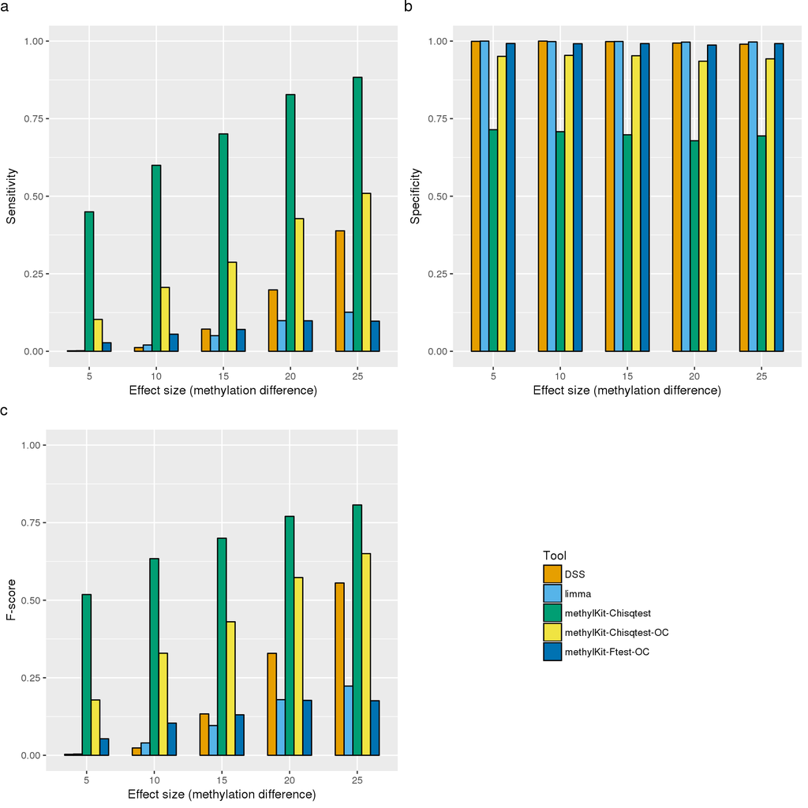

```r
#dev.off()



# 1. Create the plots the plots for sensitivity, specificity and F-score
#++++++++++++++++++++++++++++++++++

# A palette
cbPalette <- c( "#E69F00", "#56B4E9", "#009E73", "#F0E442", "#0072B2", "#D55E00", "#CC79A7")

p_sens<-ggplot(models.res.df,aes(effect, sens, fill=tool))+
  geom_bar(stat="identity",position='dodge',colour="black",
           width=0.65)+
  coord_cartesian(ylim=c(0.0,1.00))+
  scale_fill_manual(values=cbPalette)+
  labs(y="Sensitivity", x="Effect size (methylation difference)",fill='Tool')


p_spec<-ggplot(models.res.df,aes(effect, spec, fill=tool))+
  geom_bar(stat="identity",
           position="dodge",
           colour="black",
           width=0.65)+
  coord_cartesian(ylim=c(0.0,1.00))+
  scale_fill_manual(values=cbPalette)+
  labs(y="Specificity", x="Effect size (methylation difference)",fill='Tool')+
  theme(legend.position = "none")

p_recall <- ggplot(models.res.df,aes(effect, recall, fill=tool))+
  geom_bar(stat="identity",position='dodge',colour="black",
           width=0.65)+
  coord_cartesian(ylim=c(0.0,1.00))+
  scale_fill_manual(values=cbPalette)+
  labs(y="Recall", x="Effect size (methylation difference)",fill='Tool')+
  theme(legend.position = "none")

p_fscore <- ggplot(models.res.df,aes(effect, f_score, fill=tool))+
  geom_bar(stat="identity",position='dodge',colour="black",
           width=0.65)+
  coord_cartesian(ylim=c(0.0,1.00))+
  scale_fill_manual(values=cbPalette)+
  labs(y="F-score", x="Effect size (methylation difference)",fill='Tool')+
  theme(legend.position = "none")


# 2. Save the legend
#+++++++++++++++++++++++
get_legend<-function(myggplot){
  tmp <- ggplot_gtable(ggplot_build(myggplot))
  leg <- which(sapply(tmp$grobs, function(x) x$name) == "guide-box")
  legend <- tmp$grobs[[leg]]
  return(legend)
}
legend <- get_legend(p_sens)
# 3. Remove the legend from the box plot
#+++++++++++++++++++++++
p_sens <- p_sens+ theme(legend.position="none")


p_sens1 <- arrangeGrob(p_sens, top = textGrob("a", x=unit(0, "npc"),y=unit(1, "npc"),
                                              just=c("left","top"), gp=gpar(col="black", fontsize=14)))
p_spec1 <- arrangeGrob(p_spec, top = textGrob("b", x=unit(0, "npc"),y=unit(1, "npc"),just=c("left","top"), gp=gpar(col="black", fontsize=14)))
p_fscore1 <- arrangeGrob(p_fscore, top = textGrob("c", x=unit(0, "npc"),y=unit(1, "npc"),just=c("left","top"), gp=gpar(col="black", fontsize=14)))


#pdf("./figs_publication/simulated_rates.pdf", width = 10, height = 7)
grid.arrange(p_sens1, p_spec1,
             p_fscore1, legend,
             ncol = 2, nrow=2)
```

```r
#dev.off()
```

Visualise intersections between DMCs from given tools for calling differentiall methylated cytosines for different effect sizes:

- 5
- 10
- 15
- 20
- 25

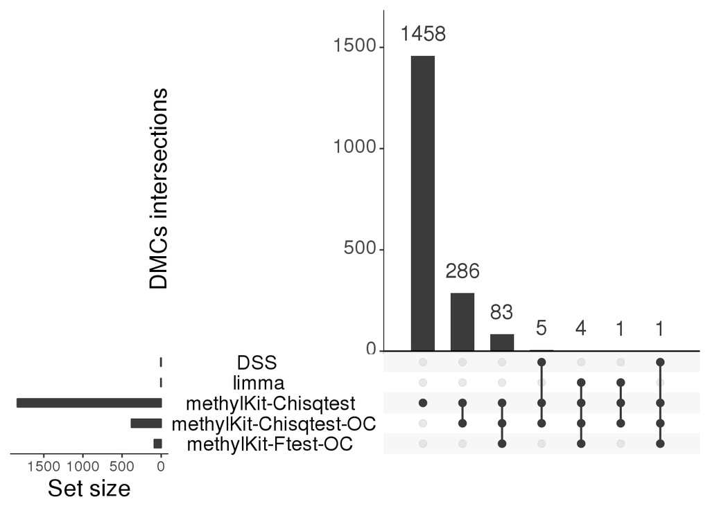

```r
source("./functions/vis.R")

#pdf("./figs_publication/plot.intersetion.tool.pdf", width = 10, height = 5)

names_sets = rev(sort(as.character(levels(models.res.df$tool)))) # to plot tools in the same order as in barplots

plot.intersetion.tools(models.res.diff[['5']], vis=TRUE, keep.order = TRUE, sets = names_sets, text.scale=c(2, 2, 2, 1.5, 2, 2.4))
```

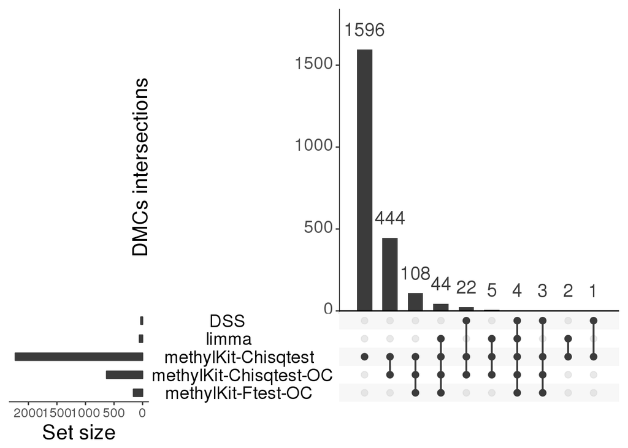

```r
plot.intersetion.tools(models.res.diff[['10']], vis=TRUE, keep.order = TRUE, sets = names_sets, text.scale=c(2, 2, 2, 1.5, 2, 2.4))
```

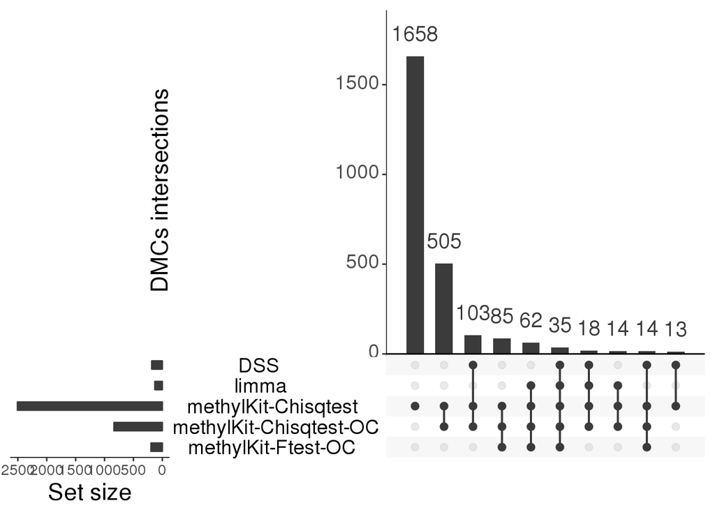

```r
plot.intersetion.tools(models.res.diff[['15']], vis=TRUE, keep.order = TRUE, sets = names_sets, text.scale=c(2, 2, 2, 1.5, 2, 2.4))
```

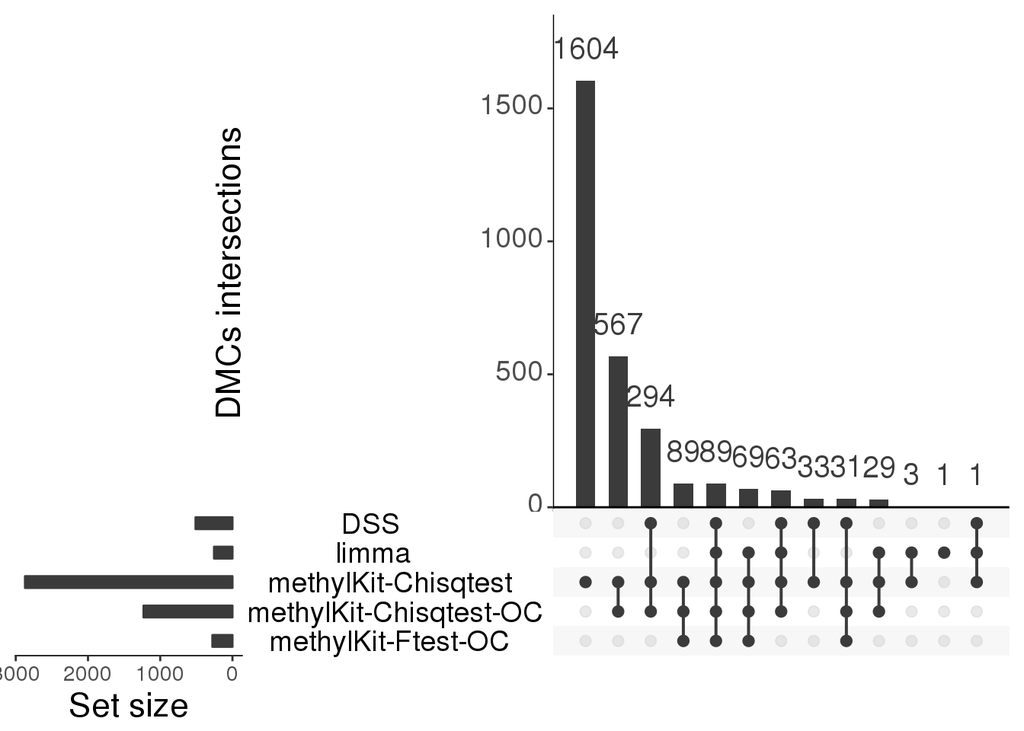

```r
plot.intersetion.tools(models.res.diff[['20']], vis=TRUE, keep.order = TRUE, sets = names_sets, text.scale=c(2, 2, 2, 1.5, 2, 2.4))
```

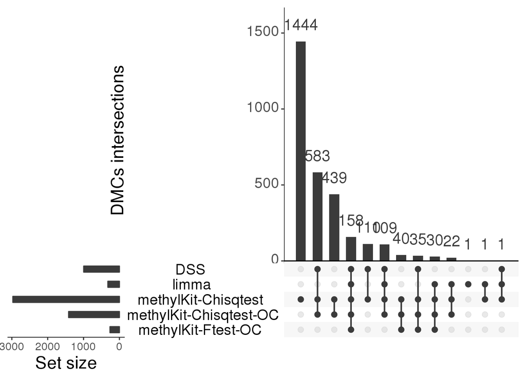

```r
plot.intersetion.tools(models.res.diff[['25']], vis=TRUE, keep.order=TRUE, sets = names_sets, text.scale=c(2, 2, 2, 1.5, 2, 2.4))
```

```r
#dev.off()
```